# EDA_modelcomparison

Sohoon Youn

2023-08-14

## (a)

```r
data = read.csv("autoswapper.csv")
```

```r
head(data)
```

```
##       make    model year price transmission mileage fuelType  mpg engineSize
## 1 Mercedes  C Class 2019 27995    Automatic    7396   Diesel 57.7          2
## 2     Ford   Fiesta 2018 11200       Manual   17971   Petrol 58.9          1
## 3  Hyundai      I10 2018  6895       Manual   30842   Petrol 60.1          1
## 4   Toyota     Aygo 2018  9831       Manual   10742   Petrol 56.5          1
## 5     Audi       A4 2019 25450    Automatic    8619   Diesel 44.8          2
## 6     Ford    Focus 2017 10930       Manual    6471   Petrol 61.4          1
```

There are 9 variables in the provided dataset. `make`, `model`, `transmission`, and `fuelType` are categorical variables, while `price`, `mileage`, `year`, `engineSize`, and `mpg` are numerical variables.

```
## [1] 0
```

There is no null values in the provided dataset.

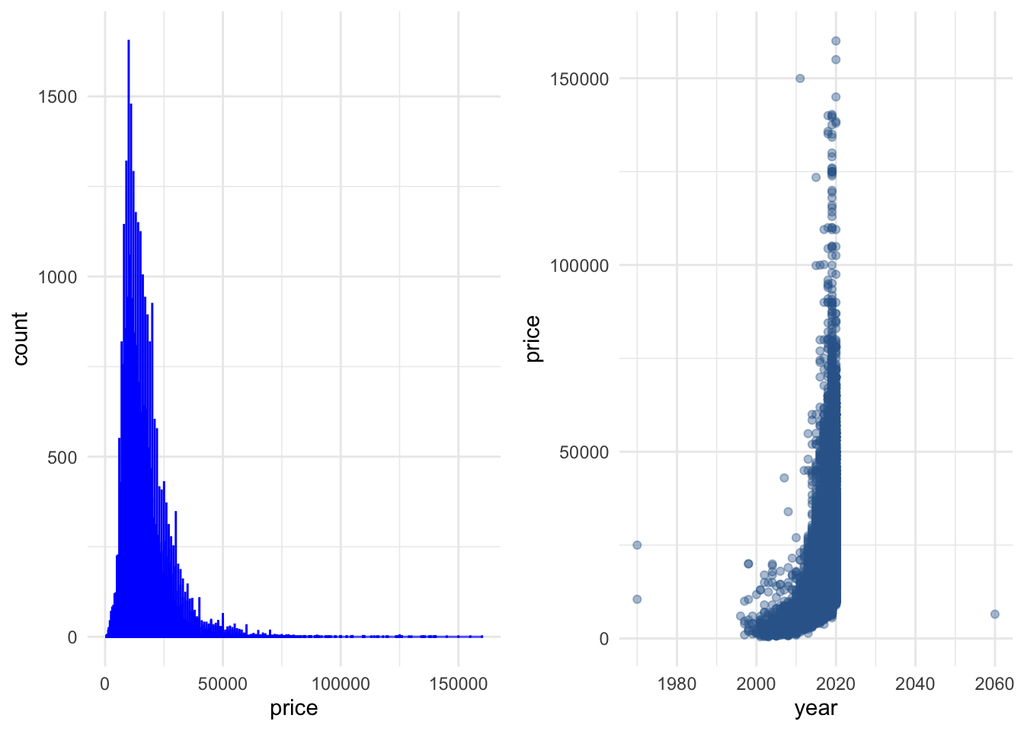

```r
p1 = ggplot(data, aes(x=price)) + geom_histogram(fill="steelblue",color="blue",binwidth=20)+theme_minimal()
p2 = ggplot(data=data, aes(x=year, y=price)) + geom_point(alpha = 0.4,color=rgb(0.2,0.4,0.6,0.6)) +
  xlab('year')+ylab('price')+theme_minimal()
ggarrange(p1, p2, ncol = 2, nrow = 1)
```

```r
summary(data$price)
```

```
##    Min. 1st Qu.  Median    Mean 3rd Qu.    Max.
##     450    9999   14495   16812   20875  159999
```

```r
summary(data$year)
```

```
##    Min. 1st Qu.  Median    Mean 3rd Qu.    Max.
##    1970    2016    2017    2017    2019    2060
```

The median and mean of the `price` variable are 14495 and 16812, respectively. The maximum value of the `price` variable is 159999. However, the majority of the data is highly concentrated between 0 and 50000. The median and mean of the year variable are both 2017. The maximum value of the `year` variable is 2060 while the minimum value is 1970. The majority of the data is highly concentrated between 2000 and 2022. There are few data points when `year`<1980 and `year`>2025. A positive correlation is identified between `price` and `year`. Specifically, the price of vehicles tends to increase as time goes on.

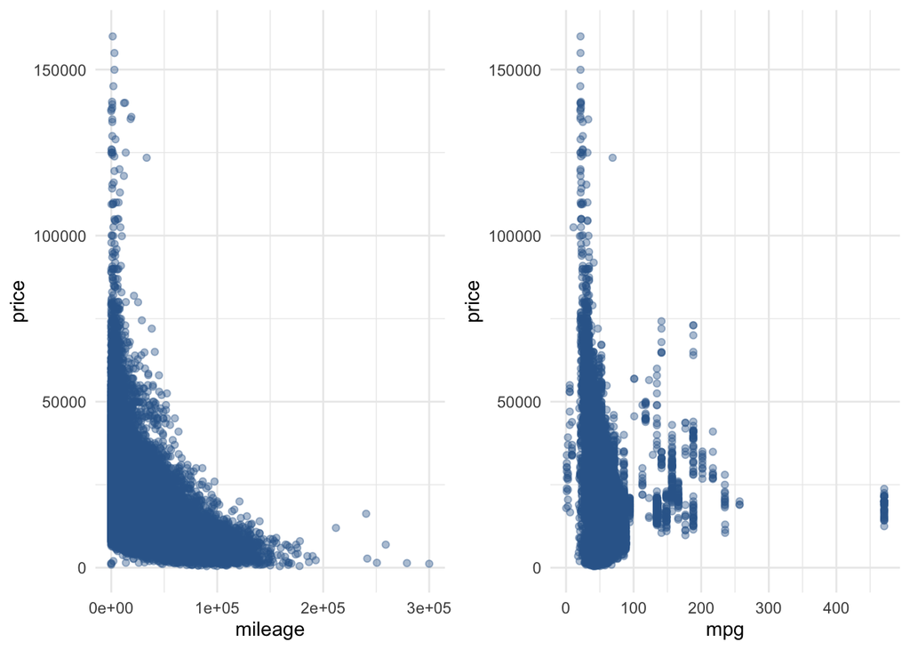

```r
p1 = ggplot(data=data, aes(x=mileage, y=price)) + geom_point(alpha = 0.4,color=rgb(0.2,0.4,0.6,0.6)) + xlab('mileage')+ylab('price')+theme_minimal()
p2 = ggplot(data=data, aes(x=mpg, y=price)) + geom_point(alpha = 0.4,color=rgb(0.2,0.4,0.6,0.6)) +
  xlab('mpg')+ylab('price')+theme_minimal()
ggarrange(p1, p2, ncol = 2, nrow = 1)
```

```r
summary(data$mileage)
```

```
##    Min. 1st Qu.  Median    Mean 3rd Qu.    Max.
##       1    7419   17455   23063   32357  300000
```

```r
summary(data$mpg)
```

```
##    Min. 1st Qu.  Median    Mean 3rd Qu.    Max.
##    0.30   47.10   54.30   55.14   62.80  470.80
```

The majority of the data is highly concentrated when variable `mileage` is between 0 and 150000, and potential outliers are identified when `mileage`>200000. The median and mean of the `mileage` variable are 17455 and 23063. A negative correlation is identified between `price` and `mileage`. To be specific, `price` decreases as `mileage` increases.

[figure not shown]

```r
p1 = ggplot(data, aes(x = make)) +
  theme_bw() +
  theme(axis.text.x = element_text(angle = 45, hjust = 1)) +
  geom_histogram(fill = "cornflowerblue", color = "black", stat="count") +
  labs(title="Price by Make", x = "Make")

p2 = ggplot(data,
       aes(x = make,
           y = price)) +
  geom_violin(fill = "cornflowerblue") +
  geom_boxplot(width = .2,
               fill = "white",
               outlier.color = "orange",
               outlier.size = 0.1) +
  theme_bw() +
  theme(axis.text.x = element_text(angle = 45, hjust = 1)) +
  labs(title = "Price Distribution by Make")

ggarrange(p1, p2, ncol = 2, nrow = 1)
```

The `make` variable is a categorical variable with the following categories: `Mercedes`, `Ford`, `Hyundai`, `Toyota`, `Audi`, `Skoda`, `BMW`, `Vauxhall`, `Volkswagen`. Most of the categories produced more than 10000 vehicles, and the majority of the vehicles in each category cost less than GBP50000.

```r
length(unique(data$model))
```

```
## [1] 194
```

```r
df1 = data.frame(data %>% group_by(model, .drop = FALSE) %>% count())
sum(df1$n<10)
```

```
## [1] 35
```

There are 194 different models in the dataset and 35 models have less than 10 counts.

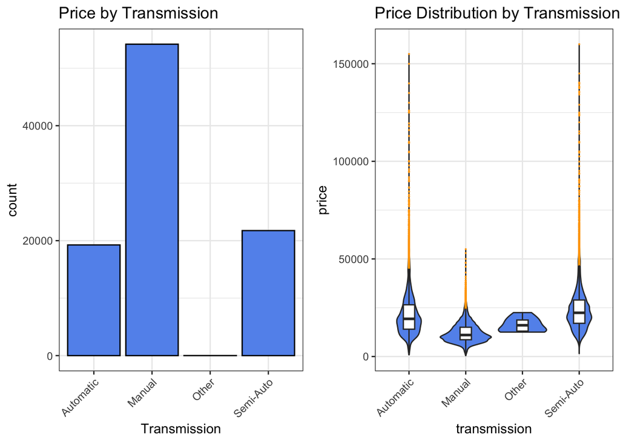

```r
p1 = ggplot(data, aes(x = transmission)) +
  geom_histogram(fill = "cornflowerblue", color = "black", stat="count") +
  theme_bw() +
  theme(axis.text.x = element_text(angle = 45, hjust = 1)) +
  labs(title="Price by Transmission", x = "Transmission")

p2 = ggplot(data,
       aes(x = transmission,
           y = price)) +
  geom_violin(fill = "cornflowerblue") +
  geom_boxplot(width = .2,
               fill = "white",
               outlier.color = "orange",
               outlier.size = 0.1) +
  theme_bw() +
  theme(axis.text.x = element_text(angle = 45, hjust = 1)) +
  labs(title = "Price Distribution by Transmission")

ggarrange(p1, p2, ncol = 2, nrow = 1)
```

```r
df1 = data.frame(data %>% group_by(transmission, .drop = FALSE) %>% count())
df1
```

```
##   transmission     n
## 1    Automatic 19254
## 2       Manual 54175
## 3        Other     9
## 4    Semi-Auto 21749
```

The `Transmission` variable is a categorical variable with the following categories: `Automatic`, `Manual`, `Semi-Auto`, `Other` categories. Most of categories produced more than 19000 vehicles, and majority of the vehicles in each category cost less than GBP50000. There are only 9 vehicles in category `Other`, but the distribution of the `price` for category `Other` is similar to that of the other three categories.

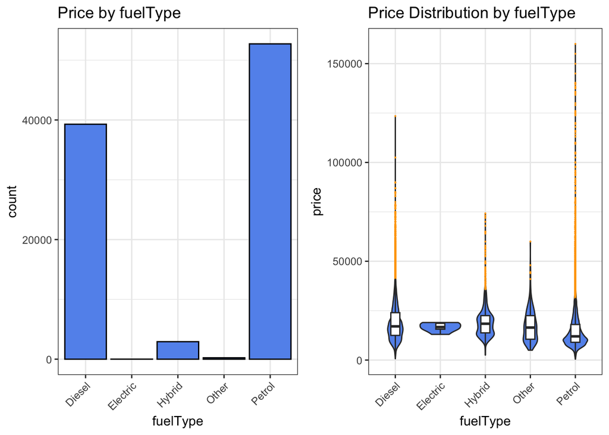

```r
p1 = ggplot(data, aes(x = fuelType)) +
  geom_histogram(fill = "cornflowerblue", color = "black", stat="count") +
  theme_bw() +
  theme(axis.text.x = element_text(angle = 45, hjust = 1)) +
  labs(title="Price by fuelType", x = "fuelType")

p2 = ggplot(data,
       aes(x = fuelType,
           y = price)) +
  geom_violin(fill = "cornflowerblue") +
  geom_boxplot(width = .2,
               fill = "white",
               outlier.color = "orange",
               outlier.size = 0.1) +
  theme_bw() +
  theme(axis.text.x = element_text(angle = 45, hjust = 1)) +
  labs(title = "Price Distribution by fuelType")

ggarrange(p1, p2, ncol = 2, nrow = 1)
```

```r
df1 = data.frame(data %>% group_by(fuelType, .drop = FALSE) %>% count())
df1
```

```
##   fuelType     n
## 1   Diesel 39292
## 2 Electric     6
## 3   Hybrid  2927
## 4    Other   234
## 5   Petrol 52728
```

The `fuelType` variable is a categorical variable with the following categories: `Diesel`, `Petrol`, `Hybrid`, `Other`, and `Electric`. More than 90% of vehicles belong to the `Diesel` and `Petrol` while there are only 6 vehicles in the `Electric` category. There are less than 3000 vehicles in categories `Hybrid`, `Other`, and `Electric`, respectively, but the distribution of the `price` for each of three categories is similar to that of the other two categories.

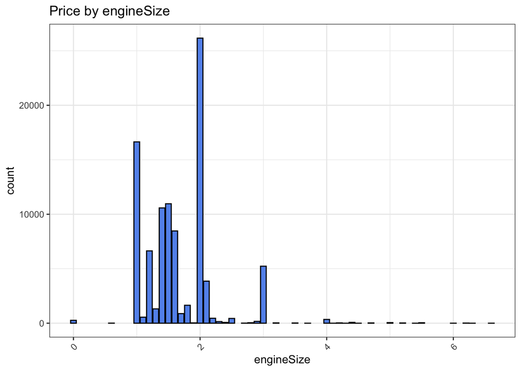

```r
ggplot(data, aes(x = engineSize)) +
  geom_histogram(fill = "cornflowerblue", color = "black", stat="count") +
  theme_bw() +
  theme(axis.text.x = element_text(angle = 45, hjust = 1)) +
  labs(title="Price by engineSize", x = "engineSize")
```

```r
df1 = data.frame(data %>% group_by(engineSize, .drop = FALSE) %>% count())
summary(df1$engineSize)
```

```
##    Min. 1st Qu.  Median    Mean 3rd Qu.    Max.
##   0.000   1.775   2.850   3.170   4.425   6.600
```

```r
dim(df1)
```

```
## [1] 40  2
```

```r
sum(df1$n<10)
```

```
## [1] 10
```

# (b) Three candidate models

- **Linear Model**

The linear model is a relatively simple statistical method to fit a model to a given dataset. The linear pattern between the response variable and the explanatory variables are found by drawing scatter plots. The interaction term is identified using a scatter plot and a correlation coefficient. By putting the square root in the response variable in `lm()`, it normalizes a skewed distribution. Also, it transforms a non-linear relationship between two variables into a linear one, reducing heteroscedasticity of the residuals in linear regression and focusing on visualizing certain parts of the dataset.

```
m1 = lm((price)^(1/2) ~ make+model+transmission+fuelType+mpg+engineSize+year*mileage, data=data)
```

- **Smoothing Spline**

The smoothing spline model is a statistical method used to fit a smooth curve to a given dataset. The algorithm works by minimizing the sum of squared residuals subject to a constraint on the roughness of the curve. The roughness penalty is controlled by a smoothing parameter that determines the trade-off between fitting the data and having a smooth curve.

```
ss = gam(price ~ make + model + transmission + fuelType + s(mpg,k=15)
    + s(engineSize,k=15) + s(year,k=5) + s(mileage,k=12)
    + ti(year, mileage,k=18), data = data)
```

- **Random Forest**

The random forest is a machine learning algorithm that uses an ensemble of decision trees to make predictions on a given dataset. The algorithm works by constructing multiple decision trees and combining their predictions to produce a final output. Each decision tree is constructed using a random subset of the features in the dataset, which helps to reduce overfitting and improve the accuracy of the model.

The importance of each variable is measured by the percentage increase in the mean squared error (MSE) when that variable is removed from the model via `importance(full model)`. According to this function, all the variables show the significantly greater values in X.IncMSE. Therefore, all the variables are added to the random forests.

Hyperparameters (mtry, ntree, maxnodes, nodesize, sampsize) are tuned by 10-fold cross validation.

```
rf = randomForest(price~make+model+transmission+fuelType+mpg+engineSize+year+mileage,
               mtry = 4, ntree=1000, maxnodes= 500, nodesize = 50, sampsize = 50000,
               data = data, importance=TRUE)
```

# (c) My predictive modeling methodology

In general, linear models have a huge limitation of its sensitivy to outliers, while smoothing splines are relatively flexible due to a smoothing parameter. Also, random forests are less sensitive to outliers as multiple decision trees and combining their predictions to produce a final output.

The final model is chosen based on the 10-fold cross validation error. K-fold cross-validation is a resampling technique used to evaluate models. It splits the data set into a K number of sections/folds. Each fold is used as a testing set once, while the rest are used as training sets. This helps to check the performance of the model on new data and avoid overfitting, underfitting, or generalizing.

Three models, m1, ss, rf, got cross validation error, 19371.58, 3068.319, 3024.309, respectively. Hence, the random forest (rf) is chosen as the final predictive model.

### Step 1 Significant varialbes

The importance of each variable is measured by the percentage increase in the mean squared error (MSE) when that variable is removed from the model via `importance(full model)`. According to this function, all the variables show the significantly greater values in X.IncMSE. Therefore, all the variables are added to the random forests.

### Step 3 Tunning parameters

The ranges for each hyperparameter(mtry, ntree, maxnodes, nodesize, sampsize) are randomly chosen, and those hyperparameters are tuned by 10-fold cross-validation. A random forest is fitted with all the combinations of hyperparameters according to the hyperparams, then the hyperparameters with the least mean squared error are chosen to the the final model.

### Step 4 Choosing a final model

The final random forest is chosen based on the lowest 10-fold cross validation score.

```
rf = randomForest(price~make+model+transmission+fuelType+mpg+engineSize+year+mileage,
               mtry = 4, ntree=1000, maxnodes= 500, nodesize = 50, sampsize = 50000,
               data = data, importance=TRUE)
```

### * The limitations of random forests

Random forests are a powerful algorithm that can provide accurate predictions for both classification and regression problems. However, it has some limitations in terms of interpretability, training time, and memory usage. It is not easily interpretable and does not provide complete visibility into the coefficients as linear regression. Also, a large number of trees can make the algorithm too slow and ineffective for real-time predictions.

# outliers

```r
dtest=read.csv("autoswapper_test.csv")
```

```r
Model <- function(dtrain, dtest){
    # Train the model
    fit = randomForest(price~make+model+transmission+fuelType+mpg+engineSize+year+mileage,
                   mtry = 4, ntree=1000, maxnodes= 500, nodesize = 50, sampsize = 50000,
                   data = data, importance=TRUE)
    pred = predict(fit, newdata=dtest)
    res = data.frame(Id=dtest$testID, price=pred)
    return(res)
}
```

```r
res = Model(data, dtest)
write.csv(res, file="username_price_suggestions.csv", row.names=FALSE)
```